# Unsupervised Learning Project

### Submitter : Sushant Kumar Gadi(sushantgadi@gmail.com)

```python
# Importing libraries

#Common libraries
import pandas as pd
import numpy as np
import matplotlib.pyplot as plt
%matplotlib inline
import seaborn as sns

#Libraries for generic model building and reporting
from sklearn import metrics
from sklearn.model_selection  import train_test_split
from scipy.stats import zscore
from scipy.spatial.distance import cdist, pdist

#Libraries for clustering algorithms
from sklearn.cluster import KMeans, AgglomerativeClustering
from scipy.cluster.hierarchy import cophenet, dendrogram, linkage

from sklearn import svm
from sklearn.preprocessing import MinMaxScaler, StandardScaler
from sklearn.model_selection import GridSearchCV
from sklearn.decomposition import PCA
from sklearn.model_selection import train_test_split
from sklearn.svm import SVC
from sklearn.metrics import accuracy_score
from sklearn.metrics import classification_report

from sklearn.linear_model import LinearRegression
```

```python
#Part 1.1 a - Read ‘Car name.csv’ as a DataFrame and assign it to a variable.

# Importing car names available in csv file
car_name = pd.read_csv("Part1+-+Car+name.csv")
car_name.head(5)
```

|  | car_name |
| --- | --- |
| 0 | chevrolet chevelle malibu |
| 1 | buick skylark 320 |
| 2 | plymouth satellite |
| 3 | amc rebel sst |
| 4 | ford torino |

```python
#Part 1.1 b - Read ‘Car-Attributes.json as a DataFrame and assign it to a variable.

# Importing car attributes available in json file
car_attr = pd.read_json("Part1+-+Car-Attributes.json")
car_attr.head(5)
```

|  | mpg | cyl | disp | hp | wt | acc | yr | origin |
| --- | --- | --- | --- | --- | --- | --- | --- | --- |
| 0 | 18.0 | 8 | 307.0 | 130 | 3504 | 12.0 | 70 | 1 |
| 1 | 15.0 | 8 | 350.0 | 165 | 3693 | 11.5 | 70 | 1 |
| 2 | 18.0 | 8 | 318.0 | 150 | 3436 | 11.0 | 70 | 1 |
| 3 | 16.0 | 8 | 304.0 | 150 | 3433 | 12.0 | 70 | 1 |
| 4 | 17.0 | 8 | 302.0 | 140 | 3449 | 10.5 | 70 | 1 |

```python
print(car_name.shape)
print(car_attr.shape)
```

```
(398, 1)
(398, 8)
```

```python
#Part 1.1 c - Merge both the DataFrames together to form a single DataFrame
# Concatenating the two dataframes
car_data = pd.concat([car_name, car_attr],axis=1)
car_data.head(5)
```

|  | car_name | mpg | cyl | disp | hp | wt | acc | yr | origin |
| --- | --- | --- | --- | --- | --- | --- | --- | --- | --- |
| 0 | chevrolet chevelle malibu | 18.0 | 8 | 307.0 | 130 | 3504 | 12.0 | 70 | 1 |
| 1 | buick skylark 320 | 15.0 | 8 | 350.0 | 165 | 3693 | 11.5 | 70 | 1 |
| 2 | plymouth satellite | 18.0 | 8 | 318.0 | 150 | 3436 | 11.0 | 70 | 1 |
| 3 | amc rebel sst | 16.0 | 8 | 304.0 | 150 | 3433 | 12.0 | 70 | 1 |
| 4 | ford torino | 17.0 | 8 | 302.0 | 140 | 3449 | 10.5 | 70 | 1 |

```python
print(car_data.shape)
```

```
(398, 9)
```

```python
# Exporting data to local in all three file formats
car_data.to_csv("Car Data.csv")
car_data.to_json("Car Data.json")
car_data.to_excel("Car Data.xlsx")
```

```python
#Part 1.1 d - Print 5 point summary of the numerical features and share insights.
car_data.describe()
```

|  | mpg | cyl | disp | wt | acc | yr | origin |
| --- | --- | --- | --- | --- | --- | --- | --- |
| count | 398.000000 | 398.000000 | 398.000000 | 398.000000 | 398.000000 | 398.000000 | 398.000000 |
| mean | 23.514573 | 5.454774 | 193.425879 | 2970.424623 | 15.568090 | 76.010050 | 1.572864 |
| std | 7.815984 | 1.701004 | 104.269838 | 846.841774 | 2.757689 | 3.697627 | 0.802055 |
| min | 9.000000 | 3.000000 | 68.000000 | 1613.000000 | 8.000000 | 70.000000 | 1.000000 |
| 25% | 17.500000 | 4.000000 | 104.250000 | 2223.750000 | 13.825000 | 73.000000 | 1.000000 |
| 50% | 23.000000 | 4.000000 | 148.500000 | 2803.500000 | 15.500000 | 76.000000 | 1.000000 |
| 75% | 29.000000 | 8.000000 | 262.000000 | 3608.000000 | 17.175000 | 79.000000 | 2.000000 |
| max | 46.600000 | 8.000000 | 455.000000 | 5140.000000 | 24.800000 | 82.000000 | 3.000000 |

#### Below is the insight of the data

```
1. mpg (Miles Per Gallon):
   - Count: There are 398 data points available for this attribute.
   - Mean: The average miles per gallon is approximately 23.51.
   - Standard Deviation (std): The dispersion of values around the mean is about 7.82, indicating a moderate level of variability.
   - Min: The minimum observed miles per gallon is 9.
   - 25%: 25% of the data points have miles per gallon values of 17.5 or lower.
   - Median (50%): The middle value of the data set is 23, which is also the median miles per gallon.
   - 75%: 75% of the data points have miles per gallon values of 29 or lower.
   - Max: The maximum observed miles per gallon is 46.6.

2. cyl (Number of Cylinders):
   - Similar statistical measures as above apply to this column. It has an average of about 5.45 cylinders.

3. disp (Displacement):
   - This column represents the engine displacement in cubic inches.
   - Again, similar statistics apply. The average displacement is about 193.43 cubic inches.

4. wt (Weight):
   - This represents the weight of the vehicle.
   - The average weight is approximately 2970.42 lbs.

5. acc (Acceleration):
   - This attribute indicates the time taken by the vehicle to accelerate from 0 to 60 mph.
   - The average acceleration time is about 15.57 seconds.

6. yr (Year):
   - This represents the manufacturing year of the vehicles.
   - The average year is around 1976.01.

7. origin:
   - This attribute likely represents the country of origin for the vehicles (1 for USA, 2 for Europe, 3 for Asia).
   - The mean value is approximately 1.57, which might suggest that the dataset is skewed towards vehicles from the USA.
```

```python
car_data.info()
```

```
<class 'pandas.core.frame.DataFrame'>
RangeIndex: 398 entries, 0 to 397
Data columns (total 9 columns):
 #   Column    Non-Null Count  Dtype
---  ------    --------------  -----
 0   car_name  398 non-null    object
 1   mpg       398 non-null    float64
 2   cyl       398 non-null    int64
 3   disp      398 non-null    float64
 4   hp        398 non-null    object
 5   wt        398 non-null    int64
 6   acc       398 non-null    float64
 7   yr        398 non-null    int64
 8   origin    398 non-null    int64
dtypes: float64(3), int64(4), object(2)
memory usage: 28.1+ KB
```

#### Comment : hp data type is object. It is expected to be numeric (int/float), so probabaly there are some unexpected characters

```python
#Part 1.2 a - Check and print feature-wise percentage of missing values present in the data and impute with the best suitable approach.

# Identifying the rows that are not digits in the hp column
test = pd.DataFrame(car_data.hp.str.isdigit())
test[test['hp'] == False]
```

|  | hp |
| --- | --- |
| 32 | False |
| 126 | False |
| 330 | False |
| 336 | False |
| 354 | False |
| 374 | False |

```python
# Calculate the percentage of missing values for each feature
missing_percentage = (car_data.isnull().sum() / len(car_data)) * 100
print("Missing Percentage:\n", missing_percentage)
```

```
Missing Percentage:
 car_name    0.0
mpg         0.0
cyl         0.0
disp        0.0
hp          0.0
wt          0.0
acc         0.0
yr          0.0
origin      0.0
dtype: float64
```

```python
#Part 1.2 b - Check for duplicate values in the data and impute with the best suitable approach.
# Replacing the data with nan

# Check for duplicate rows
duplicates = car_data.duplicated()
print("Duplicate Rows:")
print(car_data[duplicates])

car_data = car_data.replace('?', np.nan)
car_data.info()
```

```
Duplicate Rows:
Empty DataFrame
Columns: [car_name, mpg, cyl, disp, hp, wt, acc, yr, origin]
Index: []
<class 'pandas.core.frame.DataFrame'>
RangeIndex: 398 entries, 0 to 397
Data columns (total 9 columns):
 #   Column    Non-Null Count  Dtype
---  ------    --------------  -----
 0   car_name  398 non-null    object
 1   mpg       398 non-null    float64
 2   cyl       398 non-null    int64
 3   disp      398 non-null    float64
 4   hp        392 non-null    float64
 5   wt        398 non-null    int64
 6   acc       398 non-null    float64
 7   yr        398 non-null    int64
 8   origin    398 non-null    int64
dtypes: float64(4), int64(4), object(1)
memory usage: 28.1+ KB
```

```python
# Converting the column data type to float
car_data['hp'] = car_data['hp'].astype('float64')
```

```python
# Replacing the nan with median of the column
numeric_cols = car_data.drop('car_name', axis=1)
car_names = pd.DataFrame(car_data[['car_name']])
numeric_cols = numeric_cols.apply(lambda x: x.fillna(x.median()),axis=0)

# Recreating Car_raw_data by combining numerical columns with car names
car_data = numeric_cols.join(car_names)
car_data.info()
```

```
<class 'pandas.core.frame.DataFrame'>
RangeIndex: 398 entries, 0 to 397
Data columns (total 9 columns):
 #   Column    Non-Null Count  Dtype
---  ------    --------------  -----
 0   mpg       398 non-null    float64
 1   cyl       398 non-null    int64
 2   disp      398 non-null    float64
 3   hp        398 non-null    float64
 4   wt        398 non-null    int64
 5   acc       398 non-null    float64
 6   yr        398 non-null    int64
 7   origin    398 non-null    int64
 8   car_name  398 non-null    object
dtypes: float64(4), int64(4), object(1)
memory usage: 28.1+ KB
```

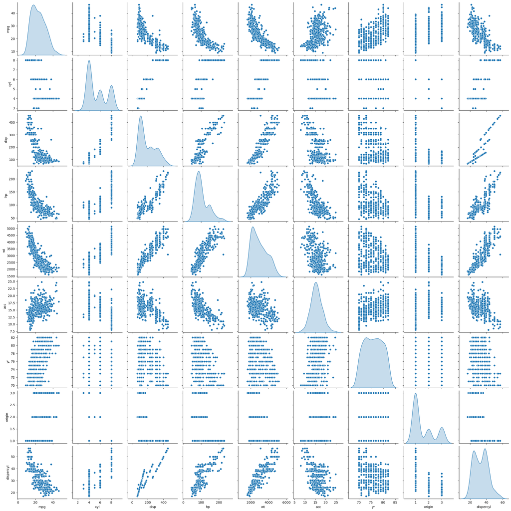

```python
#Part 1.2 c - Plot a pairplot for all features.

# This is done using scatter matrix function which creates a dashboard reflecting useful information about the dimensions
# The result can be stored as a .png file and opened in say, paint to get a larger view

car_df_attr = car_data.iloc[:, 0:8]
car_df_attr['dispercyl'] = car_df_attr['disp'] / car_df_attr['cyl']
sns.pairplot(car_df_attr, diag_kind='kde')
```

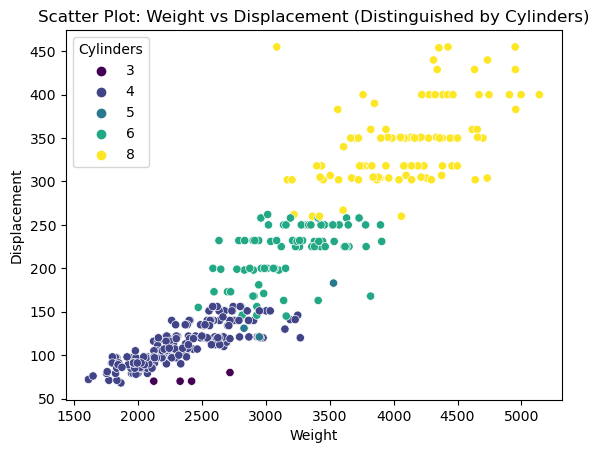

```python
#Part 1.2 d - Visualize a scatterplot for ‘wt’ and ‘disp’. Datapoints should be distinguishable by ‘cyl’.

# Create a scatter plot using Seaborn
sns.scatterplot(data=car_data, x='wt', y='disp', hue='cyl', palette='viridis')
plt.xlabel('Weight')
plt.ylabel('Displacement')
plt.title('Scatter Plot: Weight vs Displacement (Distinguished by Cylinders)')
plt.legend(title='Cylinders')
plt.show()
```

#### Part 1.2 e - Share insights for Q2.d.

##### Overall, the scatter plot shows that there is a strong relationship between weight and displacement, and that this relationship is influenced by the number of cylinders. This information can be useful for car buyers who are looking for a specific performance or fuel economy profile.

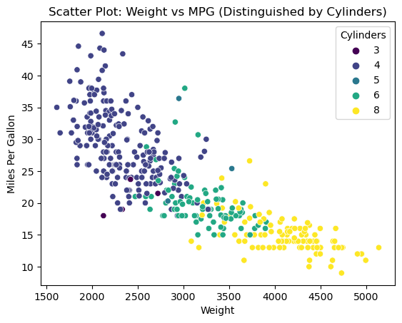

```python
#Part 1.2 f - Visualize a scatterplot for ‘wt’ and ’mpg’. Datapoints should be distinguishable by ‘cyl’.

# Create a scatter plot using Seaborn
sns.scatterplot(data=car_data, x='wt', y='mpg', hue='cyl', palette='viridis')
plt.xlabel('Weight')
plt.ylabel('Miles Per Gallon')
plt.title('Scatter Plot: Weight vs MPG (Distinguished by Cylinders)')
plt.legend(title='Cylinders')
plt.show()
```

#### Part 1.2 g- Share insights for Q2.f.

##### The scatterplot can also be used to compare different types of cars. For example, we can see that cars with 8 cylinders tend to be heavier and get lower mpg than cars with 4 cylinders. This information can be useful when making decisions about which type of car to buy.